# breakclone: Estimating clonal relatedness probability between tumour pairs

Maria Roman Escorza (maria.roman-escorza@kcl.ac.uk)

2024-11-26

# 1 Introduction

When a cancer patient develops a new tumor, it’s crucial to determine whether the new tumor is a recurrence (metastasis) of the original cancer or a completely new instance of the disease. Since each tumor carries a unique profile of somatic genomic alterations, it is theoretically possible to provide a more definitive diagnosis in these difficult cases by comparing the genomic patterns of the two tumors.

## 1.1 Citation

If you find this tool useful, please cite:

*Lips EH, Kumar T, Megalios A, et al. 2022. Genomic analysis defines clonal relationships of ductal carcinoma in situ and recurrent invasive breast cancer. [Nature Genetics](https://doi.org/10.1038/s41588-022-01082-3)*

# 2 Installation

```r
if (!require("devtools")) {
  install.packages("devtools")
}

devtools::install_github("Sawyer-s-Group/breakclone")
```

# 3 Overview of the package

`breakclone` functions can be categorized into mainly Reading, Visualization and Analysis modules. breakclone can be run in three modes depending on your data: `alleleSpecific` for the allele-specific copy number data, `VCF` for the non-allele specific copy number data and **mutation** data. Each of these functions and a short description is summarized as shown below.

[figure not shown]

We load the package and the datasets that will be used in this vignette:

```r
library(breakclone)
data(segmentTable_AS)
data(segmentTable)
data(mutationTable)
```

# 4 Preparing input data

`breakclone` takes advantage of fast `data.table`, an extension of `data.frame` which allows fast aggregation of large data. If you prefer to use alternative methods to read your data than the proposed by the package, please make sure you transform it to the appropiate formate using `data.table::as.data.table()`.

Minimal inputs for running brekclone are:

- Aberrations `data.table` (called `segmentTable` in copy number functions and `mutationTable`).
- paired IDs `data.table` (`pairs`).

## 4.1 `segmentaTable` input for non-allele-specific data

`readVCFCn` automatically reads copy number data from standard VCF files.

```r
segmentTable <- readVCFCn("/path/to/data")
```

```r
class(segmentTable)
```

```
#> [1] "data.table" "data.frame"
```

```r
head(segmentTable)
```

```
#>             SampleID    Chr     Start       End  Bins SVType    Length
#>               <char> <char>     <int>    <char> <int> <char>     <int>
#> 1: Patient53_Primary      1 143600001 248900000   955    DUP 105300000
#> 2: Patient53_Primary      2  11500001  12600000    11    DEL   1100000
#> 3: Patient53_Primary      5    100001  50400000   292    DUP  50300000
#> 4: Patient53_Primary      6    400001  94800000   861    DUP  94400000
#> 5: Patient53_Primary      6 101800001 107200000    35    DUP   5400000
#> 6: Patient53_Primary      6 118800001 121300000    25    DUP   2500000
```

## 4.2 `segmentTable` input for allele-specific data

`readAlleleSpecific` automatically reads text files with columns for sample IDs, chromosome, start, end, number of probes, number of copies in the major and minor allele.

```r
segmentTable_AS <- readAlleleSpecific("/path/to/data")
```

```r
class(segmentTable_AS)
```

```
#> [1] "data.table" "data.frame"
```

```r
head(segmentTable_AS)
```

```
#>            SampleID    Chr     Start       End nProbes nMajor nMinor
#>              <char> <char>     <int>     <int>   <int>  <int>  <int>
#> 1: Patient1_Primary      1    752566  93527769    9705      4      2
#> 2: Patient1_Primary      1  93544629 249202755   10663      4      1
#> 3: Patient1_Primary      2     72184 170303507   15365      3      2
#> 4: Patient1_Primary      2 170305273 170981375      82      4      2
#> 5: Patient1_Primary      2 170996360 171873033     139      3      2
#> 6: Patient1_Primary      2 171893117 175957888     526      4      2
```

## 4.3 `mutationTable` input

`readVCFMutations` automatically reads mutations from standard VCF files. It is recommended to include annotation for visualization purposes.

```r
mutationTable <- readVCFMutations("/path/to/data")
```

```r
class(mutationTable)
```

```
#> [1] "data.table" "data.frame"
```

```r
head(mutationTable)
```

```
#>             SampleID    Chr       Pos     AF annotation
#>               <char> <char>     <int>  <num>     <char>
#> 1: Patient43_Primary     17   7674230 0.4489       TP53
#> 2: Patient35_Primary     17   7675088 0.3202       TP53
#> 3: Patient47_Primary     17   7675088 0.9669       TP53
#> 4: Patient46_Primary      3 179218303 0.4335     PIK3CA
#> 5: Patient32_Primary      3 179218303 0.6620     PIK3CA
#> 6: Patient38_Primary      3 179218303 0.6518     PIK3CA
```

## 4.4 `pairs` input

`pairs` is a table of paired samples from the dataset. All tumours present in this table will be paired with all tumours from other patients. IIf sample IDs comprise a patient ID and a tumour type identifier, `inferPairs` can attempt to infer the tumour pairs from the cohort.

```r
pairs_cn <- inferPairs(segmentTable)
pairs_cnAS <- inferPairs(segmentTable_AS)
pairs_muts <- inferPairs(mutationTable)
head(pairs_muts)
```

```
#>              Sample1              Sample2   Patient
#>               <char>               <char>    <char>
#> 1:  Patient1_Primary  Patient1_Recurrence  Patient1
#> 2: Patient10_Primary Patient10_Recurrence Patient10
#> 3: Patient11_Primary Patient11_Recurrence Patient11
#> 4: Patient12_Primary Patient12_Recurrence Patient12
#> 5: Patient13_Primary Patient13_Recurrence Patient13
#> 6: Patient14_Primary Patient14_Recurrence Patient14
```

# 5 Clonality assessment using copy number

Firstly, `breakclone` generates the reference distribution of concordance scores from unpaired tumours for a given dataset. As distribution of concordance scores is calculated by randomly permuting all possible pairs from different patients, we set a seed to be able to reproduce the results of this vignette.

```r
set.seed(111)
reference <- makeReferenceCN(
  segmentTable = segmentTable,
  pairs = pairs_cn,
  cnType = "VCF"
)
```

```
#> Making reference based on 210 possible pairs, this might take a while
```

We are ready to run the clonality assessment using `calculateRelatednessCn` which calculates the relatedness scores and p-values for paired tumours from copy number data. Clonality results of copy number data can be summarized using `summarizeClonalityCN`. By default, threshold for ambiguous clonality is 0.05 and for related is 0.01.

```r
results <- calculateRelatednessCn(
  segmentTable = segmentTable,
  pairs = pairs_cn,
  reference = reference,
  cnType = "VCF"
)

summary <- summarizeClonalityCN(
  clonalityResults = results,
  segmentTable,
  thres_ambiguous = 0.05,
  thres_related = 0.01,
  cnType = "VCF"
)

head(summary)
```

```
#>             Sample1              Sample2   Patient pair_scores    pair_ps
#> 1 Patient46_Primary Patient46_Recurrence Patient46   0.6128205 0.00000000
#> 2 Patient47_Primary Patient47_Recurrence Patient47   0.2107527 0.00000000
#> 3 Patient48_Primary Patient48_Recurrence Patient48   0.2927711 0.00000000
#> 4 Patient49_Primary Patient49_Recurrence Patient49   0.1289377 0.00952381
#> 5 Patient50_Primary Patient50_Recurrence Patient50   0.1024390 0.02857143
#> 6 Patient51_Primary Patient51_Recurrence Patient51   0.3908382 0.00000000
#>     verdict shared private_sample1 private_sample2 total
#> 1   Related     12               0               2    14
#> 2   Related      9               9              35    53
#> 3   Related     31              27              77   135
#> 4   Related     15              93              59   167
#> 5 Ambiguous     10              10             134   154
#> 6   Related     78             122              64   264
#>   fraction_private_sample1 fraction_private_sample2 fraction_shared
#> 1               0.00000000                0.1428571      0.85714286
#> 2               0.16981132                0.6603774      0.16981132
#> 3               0.20000000                0.5703704      0.22962963
#> 4               0.55688623                0.3532934      0.08982036
#> 5               0.06493506                0.8701299      0.06493506
#> 6               0.46212121                0.2424242      0.29545455
```

The algorithm uses the position of the individual copy number aberration breakpoints. Concordant breakpoints can be exported using `getSharedBreaks`. Output is a list of tables including he shared breakpoints per sample.

```r
breaks <- getSharedBreaks(
  segmentTable = segmentTable,
  pairs = pairs_cn,
  cnType = "VCF",
  save = FALSE
)
breaks[[1]]
```

```
#>        seqnames    start       end break_shared
#> DUP.1         7 57900001  63300000        start
#> DUP.2        12   100001 133200000        start
#> DUP.3        16   100001  36100000        start
#> DUP.4        18   200001  80200000        start
#> DUP.5        20   100001  64200000        start
#> DEL          16 46500001  90100000        start
#> DUP.11        7 57900001  63300000          end
#> DUP.21       12   100001 133200000          end
#> DUP.31       16   100001  36100000          end
#> DUP.41       18   200001  80200000          end
#> DUP.51       20   100001  64200000          end
#> DEL1         16 46500001  90100000          end
```

Paired copy number profiles with shared CNAs and breakpoints can be visualized using `plotCNpairVCF`. Input is binned copy number data where `cnTable` represents the copy number values and `binnedTable` represents the segment mean of the copy number values, which can be extracted easily from a segmented `QDNAseq` object using the code below.

```r
binnedTable <- log2(Biobase::assayDataElement(QDNAseq_object, "segmented"))
cnTable <- log2(Biobase::assayDataElement(QDNAseq_object, "copynumber"))
```

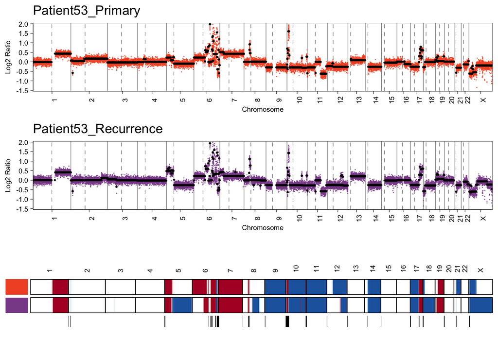

```r
data(binnedTable)
data(cnTable)

plotCNpairVCF(binnedTable,
  cnTable,
  pair = c("Patient53_Primary", "Patient53_Recurrence"),
  segmentTable = segmentTable,
  breaks = breaks,
  build = "hg38"
)
```

# 6 Clonality assessment using allele-specific copy number

```r
reference <- makeReferenceCN(
  segmentTable = segmentTable_AS,
  pairs = pairs_cnAS
)
```

```r
results <- calculateRelatednessCn(
  segmentTable = segmentTable_AS,
  pairs = pairs_cnAS,
  reference = reference
)

summary <- summarizeClonalityCN(
  clonalityResults = results,
  segmentTable = segmentTable_AS
)
head(summary)
```

```
#>             Sample1              Sample2   Patient pair_scores     pair_ps
#> 1  Patient1_Primary  Patient1_Recurrence  Patient1  0.20797642 0.000000000
#> 2 Patient10_Primary Patient10_Recurrence Patient10  0.09381840 0.002312673
#> 3 Patient11_Primary Patient11_Recurrence Patient11  0.09521933 0.002312673
#> 4 Patient12_Primary Patient12_Recurrence Patient12  0.01450677 0.318223867
#> 5 Patient13_Primary Patient13_Recurrence Patient13  0.03406949 0.133209991
#> 6 Patient14_Primary Patient14_Recurrence Patient14  0.13311170 0.000000000
#>     verdict shared private_sample1 private_sample2 total
#> 1   Related     64             178             156   398
#> 2   Related     29             255             173   457
#> 3   Related      9              77              67   153
#> 4 Unrelated      7             255             149   411
#> 5 Unrelated      6              54              92   152
#> 6   Related     15              59              71   145
#>   fraction_private_sample1 fraction_private_sample2 fraction_shared
#> 1                0.4472362                0.3919598      0.16080402
#> 2                0.5579869                0.3785558      0.06345733
#> 3                0.5032680                0.4379085      0.05882353
#> 4                0.6204380                0.3625304      0.01703163
#> 5                0.3552632                0.6052632      0.03947368
#> 6                0.4068966                0.4896552      0.10344828
```

```r
breaks <- getSharedBreaks(
  segmentTable = segmentTable_AS,
  pairs = pairs_cnAS,
  save = FALSE
)
```

# 7 Clonality assessment using mutation

For the clonality assessment using mutation data, the allele frequency is weighted according to the population frequency. A higher allele frequency is interpreted as a stronger indicator of clonal relatedness, while a higher population frequency is interpreted as diminishing the predictive value of the variant. To calculate the reference distribution of concordance scores, the TCGA Pan-Cancer Atlas breast cancer mutation calls were used available in the package as `brca`.

```r
data(brca)
head(brca)
```

```
#> GRanges object with 6 ranges and 0 metadata columns:
#>     seqnames    ranges strand
#>        <Rle> <IRanges>  <Rle>
#>   1    chr14 104780214      *
#>   2    chr14 104780214      *
#>   3    chr14 104780214      *
#>   4    chr14 104780214      *
#>   5    chr14 104780214      *
#>   6    chr14 104780214      *
#>   -------
#>   seqinfo: 15 sequences from an unspecified genome; no seqlengths
```

```r
reference <- makeReferenceMutations(
  mutationTable = mutationTable,
  pairs = pairs_muts,
  additionalMutations = brca,
  nAdditionalSamples = 346
)
```

```
#> Making reference based on 2070 possible pairs, this might take a while
```

We are ready to run the clonality assessment using `calculateRelatednessMutations` which calculates the relatedness scores and p-values for paired tumours from mutation data. Results can be summarized using `summarizeClonalityMuts`.

```r
results <- calculateRelatednessMutations(
  mutationTable = mutationTable,
  pairs = pairs_muts,
  reference = reference,
  additionalMutations = brca,
  nAdditionalSamples = 346
)

summary <- summarizeClonalityMuts(
  clonalityResults = results,
  mutationTable = mutationTable
)
head(summary)
```

```
#>             Sample1              Sample2   Patient pair_scores     pair_ps
#> 1  Patient1_Primary  Patient1_Recurrence  Patient1           1 0.006280193
#> 2 Patient10_Primary Patient10_Recurrence Patient10           1 0.006280193
#> 3 Patient11_Primary Patient11_Recurrence Patient11           1 0.006280193
#> 4 Patient12_Primary Patient12_Recurrence Patient12           1 0.006280193
#> 5 Patient13_Primary Patient13_Recurrence Patient13           1 0.006280193
#> 6 Patient14_Primary Patient14_Recurrence Patient14           1 0.006280193
#>   verdict shared private_sample1 private_sample2 total fraction_private_sample1
#> 1 Related      2               0               0     2                        0
#> 2 Related      1               0               0     1                        0
#> 3 Related      2               0               0     2                        0
#> 4 Related      1               0               0     1                        0
#> 5 Related      2               0               0     2                        0
#> 6 Related      4               0               0     4                        0
#>   fraction_private_sample2 fraction_shared
#> 1                        0               1
#> 2                        0               1
#> 3                        0               1
#> 4                        0               1
#> 5                        0               1
#> 6                        0               1
```

Shared mutations can be exported using `getSharedMuts` and plotted with `plotScatterVAF`. Mutations can be labelled by extra column in `mutationTable` if `annotGenes=TRUE`.

```r
shared_muts <- getSharedMuts(
  mutationTable = mutationTable,
  pairs = pairs_muts,
  save = FALSE
)
shared_muts[[4]]
```

```
#>   chr      pos AF_sample1 AF_sample2
#> 1   3 52409570     0.3175      3e-04
```

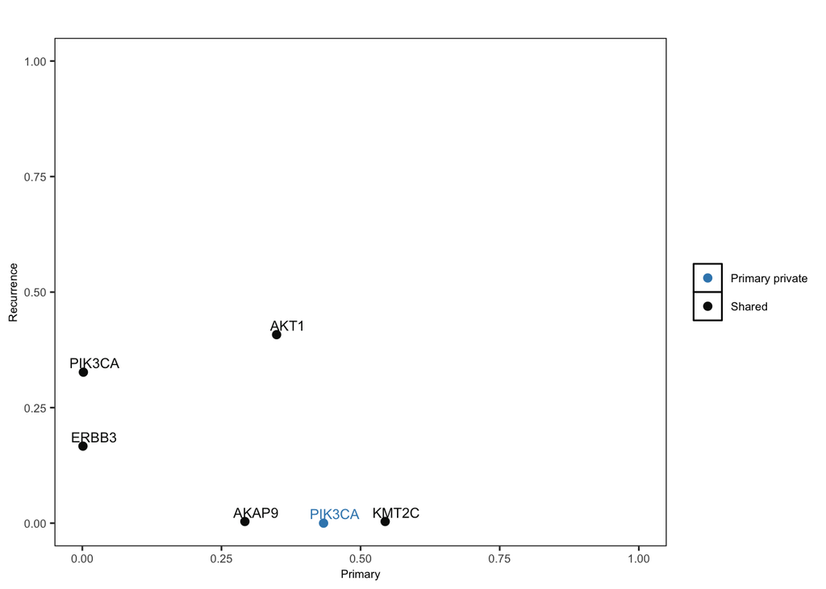

```r
plotScatterVAF(
  mutationTable = mutationTable,
  pair = c("Patient46_Primary", "Patient46_Recurrence"),
  annotGenes = TRUE
)
```

# 8 Assessement of the clonality score

`plotScoresDensity` plots the reference and pair distributions and `plotScoresHistogram` plots the reference and pair histograms.

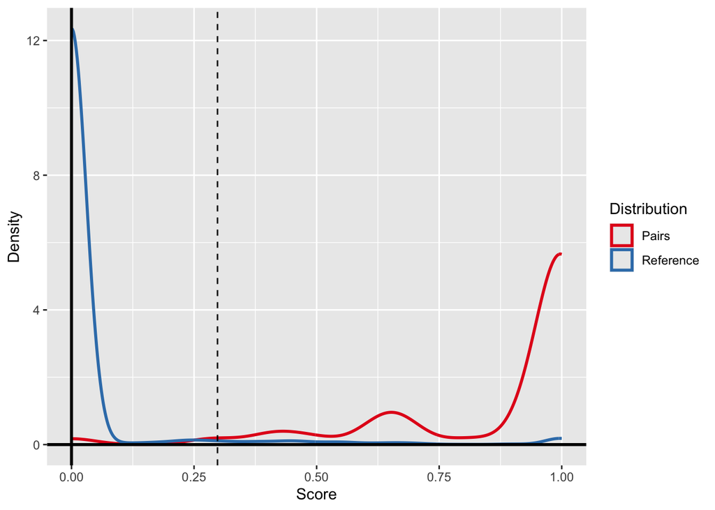

```r
plotScoresDensity(reference, results)
```

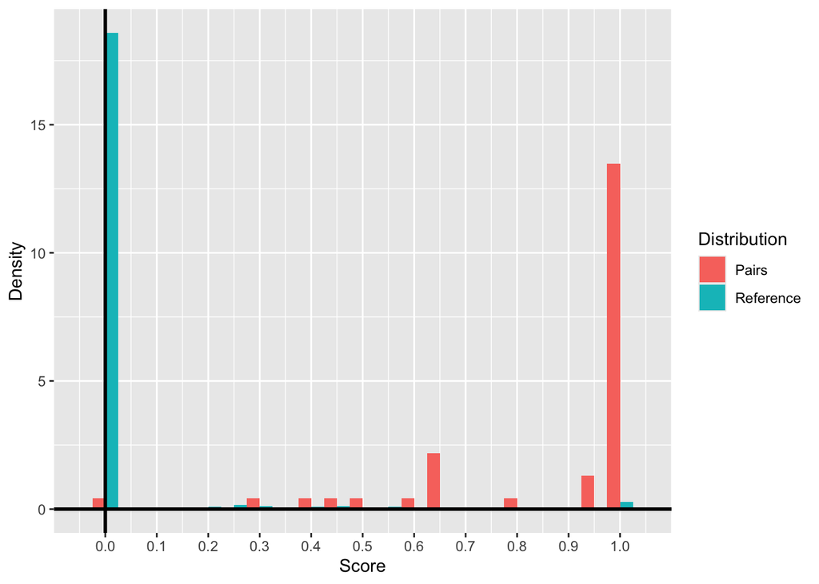

```r
plotScoresHistogram(reference, results)
```

# 9 Plot clonality results

You can plot clonality results using `plotSummary`. An extra pheno bar can be added using `extraAnno`.

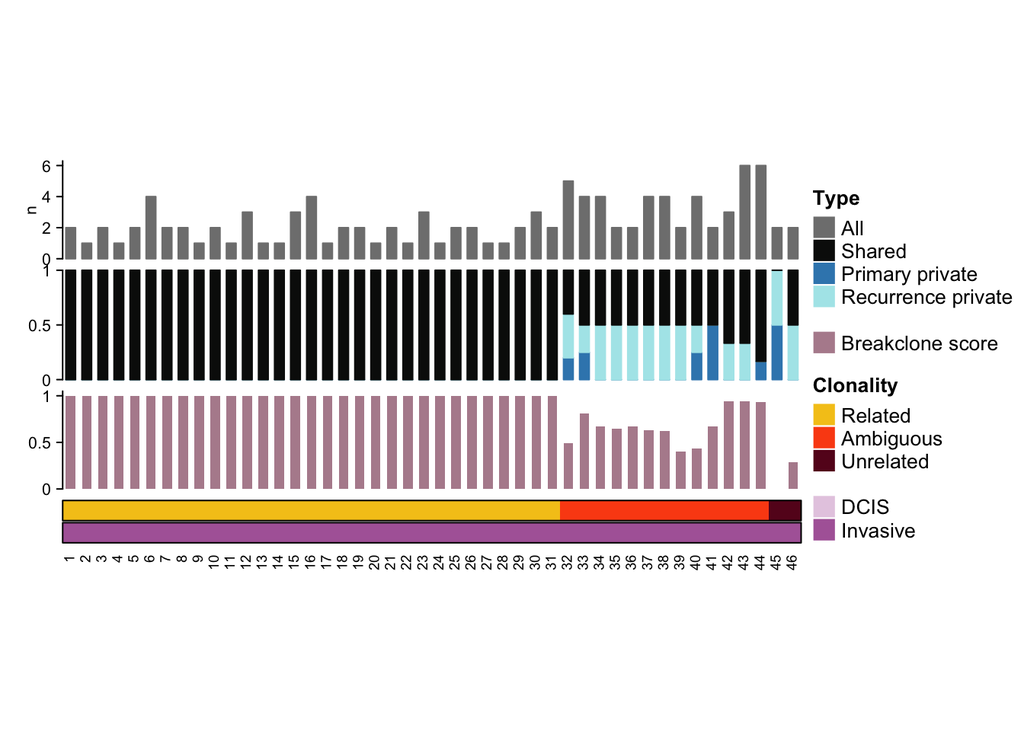

```r
plotSummary(summary,
  extraAnno = rep("Invasive", nrow(summary)),
  colorsExtraAnno = c(
    "DCIS" = "#e6cde3",
    "Invasive" = "#af67a7"
  )
)
```

# 10 Appendix: Download mutations from TCGA

This section shows how to create `additionalMutations`, a table of mutations to be taken into account when calculating population frequencies. At a minimum, a table of the mutations in the population being studied. This is more informative when tumour type-specific mutations are included from external sources (e.g. TCGA).

```r
library(TCGAretriever)

brca <- get_mutation_data(
  case_list_id = "brca_tcga_pub_complete",
  gprofile_id = "brca_tcga_pub_mutations",
  glist = unique(mutationTable$annotation)
)
brca$chr <- sub("23", "X", brca$chr) # 23 to X
brca$chr <- paste0("chr", brca$chr)
brca <- brca[brca$startPosition == brca$endPosition, ] # take only SNPs mutations
brca <- brca[brca$mutationType %in% c("Missense_Mutation", "Nonsense_Mutation", "Nonstop_Mutation", "Splice_Region", "Splice_Site", "Translation_Start_Site"), ] # filter specific mutations
```

We downloaded BRCA TCGA mutations from 346 samples using `TCGAretriever` package. `additionalMutations` needs to be transform to a `GRanges` object.

```r
brca <- makeGRangesFromDataFrame(brca,
  start.field = "startPosition",
  end.field = "endPosition",
  seqnames.field = "chr"
)
```

As the dataset used in this vignette was aligned to hg38 and TCGA to hg19, I liftover the mutations:

```r
library(liftOver)

download.file(
  "https://hgdownload.soe.ucsc.edu/gbdb/hg19/liftOver/hg19ToHg38.over.chain.gz",
  "hg19ToHg38.over.chain.gz"
)
R.utils::gunzip("hg19ToHg38.over.chain.gz", overwrite = TRUE)

ch <- import.chain("hg19ToHg38.over.chain")
brca <- unlist(liftOver(brca, ch))
```

# 12 References